# RTN: Reconstruction of Transcriptional regulatory Networks and analysis of regulons.

Clarice Groeneveld [ctb], Gordon Robertson [ctb], Xin Wang [aut], Michael Fletcher [aut], Florian Markowetz [aut], Kerstin Meyer [aut], and Mauro Castro [aut].

16 September 2019

#### Abstract

A transcriptional regulatory network (TRN) consists of a collection of regulated target genes and transcription factors (TFs). The TFs recognize specific DNA sequences and influence gene expression across the genome, either activating or repressing the expression of target genes. The set of genes controlled by a given TF forms a *regulon*. The RTN package provides classes and methods for the reconstruction of TRNs and analysis of regulons. New computational frameworks are also available from [RTNduals](http://bioconductor.org/packages/RTNduals/) and [RTNsurvival](http://bioconductor.org/packages/RTNsurvival/) packages.

#### Package

RTN 2.8.5

# 1 Overview

The **RTN** package is designed for the reconstruction of TRNs and analysis of regulons using mutual information (MI) (Fletcher et al. 2013). It is implemented by S4 classes in *R* (R Core Team 2012) and extends several methods previously validated for assessing regulons, *e.g.* MRA (Carro et al. 2010), GSEA (Subramanian et al. 2005), and EVSE (Castro et al. 2016). The package tests the association between a given TF and all potential targets using either RNA-Seq or microarray transcriptome data. It is tuned to deal with large gene expression datasets in order to build transcriptional regulatory units that are centered on TFs. **RTN** allows a user to set the stringency of the analysis in a stepwise process, including a bootstrap routine designed to remove unstable associations. Parallel data processing is available for steps that benefit from high-performance computing.

# 2 Quick Start

## 2.1 Transcriptional Network Inference (TNI)

The **TNI** pipeline starts with the generic function `tni.constructor` and creates a `TNI-class` object, which provides methods for TRN inference from high-throughput gene expression data. The `tni.constructor` takes in a matrix of normalized gene expression and the corresponding gene and sample annotations, as well as a list of regulators to be evaluated. Here, the gene expression matrix and annotations are available in the `tniData` dataset, which was extracted, pre-processed and size-reduced from Fletcher et al. (2013) and Curtis et al. (2012). This dataset consists of a list with 3 objects: a named gene expression matrix (`tniData$expData`), a data frame with gene annotations (`tniData$rowAnnotation`), and a data frame with sample annotations (`tniData$colAnnotation`). We will use this dataset to demonstrate the construction of a small TRN that has only 5 regulons. In general, though, we recommend building regulons for all TFs annotated for a given species; please see the *case study* sections for additional recommendations.

The `tni.constructor` method will check the consistency of all the given arguments. The **TNI** pipeline is then executed in three steps: (i) compute MI between a regulator and all potential targets, removing non-significant associations by permutation analysis; (ii) remove unstable interactions by bootstrapping; and (iii) apply the ARACNe algorithm. Additional comments are provided throughout the examples.

```r
library(RTN)
data(tniData)
```

```r
# Input 1: 'expData', a named gene expression matrix (genes on rows, samples on cols);
# Input 2: 'regulatoryElements', a vector listing genes regarded as TFs
# Input 3: 'rowAnnotation', an optional data frame with gene annotation
# Input 4: 'colAnnotation', an optional data frame with sample annotation
tfs <- c("FOXM1","E2F2","E2F3","RUNX2","PTTG1")
rtni <- tni.constructor(expData = tniData$expData,
                        regulatoryElements = tfs,
                        rowAnnotation = tniData$rowAnnotation,
                        colAnnotation = tniData$colAnnotation)
# p.s. alternatively, 'expData' can be a 'SummarizedExperiment' object
```

Then the `tni.permutation` function takes the pre-processed `TNI-class` object and returns a TRN inferred by permutation analysis (with corrections for multiple hypothesis testing).

```r
# Please set nPermutations >= 1000
rtni <- tni.permutation(rtni, nPermutations = 100)
```

Unstable interactions are subsequently removed by bootstrap analysis using the `tni.bootstrap` function, which creates a consensus bootstrap network, referred here as `refnet` (reference network).

```r
rtni <- tni.bootstrap(rtni)
```

At this stage each target in the TRN may be linked to multiple TFs. Because regulation can occur by both direct (TF-target) and indirect interactions (TF-TF-target), the pipeline next applies the ARACNe algorithm (Margolin, Nemenman, et al. 2006) to remove the weakest interaction in any triplet formed by two TFs and a common target gene, preserving the dominant TF-target pair (Lafitte, Bontempi, and Meyer 2008). The ARACNe algorithm uses the data processing inequality (DPI) theorem to enrich the regulons with direct TF-target interactions, creating a DPI-filtered TRN, referred here as `tnet` (transcriptional network). For additional details, please refer to Margolin, Wang, et al. (2006) and Fletcher et al. (2013). Briefly, consider three random variables, `X`, `Y` and `Z` that form a network triplet, with `X` interacting with `Z` only through `Y` (*i.e.*, the interaction network is `X->Y->Z`), and no alternative path exists between `X` and `Z`). The DPI theorem states that the information transferred between `Y` and `Z` is always larger than the information transferred between `X` and `Z`. Based on this assumption, the ARACNe algorithm scans all triplets formed by two regulators and one target and removes the edge with the smallest MI value of each triplet, which is regarded as a redundant association.

```r
rtni <- tni.dpi.filter(rtni)
```

For a summary of the resulting regulatory network we recommend using the `tni.regulon.summary` function. From the summary below, we can see the number of regulons, the number of inferred targets and the regulon size distribution.

```r
tni.regulon.summary(rtni)
## This regulatory network comprised of 5 regulons.
## -- DPI-filtered network:
## regulatoryElements            Targets              Edges
##                  5               1185               1263
##    Min. 1st Qu.  Median    Mean 3rd Qu.    Max.
##      87     221     297     253     310     348
## -- Reference network:
## regulatoryElements            Targets              Edges
##                  5               1185               2489
##    Min. 1st Qu.  Median    Mean 3rd Qu.    Max.
##      87     491     609     498     638     664
## ---
```

The `tni.regulon.summary` function also lets us get detailed information about a specific regulon, including the number of positive and negative targets. Please use this information as an initial guide in assessing the set of regulons. Usually small regulons (<15 targets) are not useful for most downstream methods, and highly unbalanced regulons (*e.g.* those with only positive targets) provide unstable activity readouts.

```r
tni.regulon.summary(rtni, regulatoryElements = "FOXM1")
## The FOXM1 regulon has 221 targets, it's a large and balanced regulon.
## -- DPI filtered network targets:
##    Total Positive Negative
##      221      140       81
## -- Reference network targets:
##    Total Positive Negative
##      609      393      216
## -- Regulators with mutual information:
## E2F2, E2F3, PTTG1
##
## ---
```

All results available in the `TNI-class` object can be retrieved using the `tni.get` accessory function. For example, setting `what = 'regulons.and.mode'` will return a list with regulons, including the weight assigned for each interaction.

```r
regulons <- tni.get(rtni, what = "regulons.and.mode", idkey = "SYMBOL")
head(regulons$FOXM1)
##    C1orf106         HBB        MAPT        HBA2     ZNF385B        FOSB
##  0.17508612 -0.10897826 -0.15494978 -0.08383799 -0.08849254 -0.10138658
```

The absolute value of a weight represents the MI value, while the sign (+/-) indicates the predicted mode of action based on the Pearson’s correlation between the regulator and its targets. We can also retrieve the inferred regulons into an `igraph-class` object (Csardi 2019) using the `tni.graph` function, which sets some basic graph attributes for visualization in the **RedeR** R package (Castro et al. 2012).

```r
g <- tni.graph(rtni, tfs = c("FOXM1","E2F2","PTTG1"))
```

The next chunk shows how to plot the `igraph-class` object using **RedeR** (**Figure 1**).

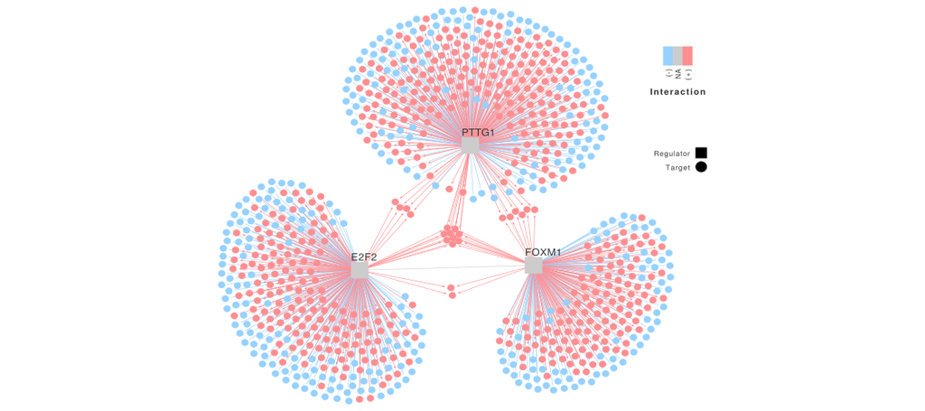

```r
library(RedeR)
rdp <- RedPort()
calld(rdp)
addGraph(rdp, g, layout=NULL)
addLegend.color(rdp, g, type="edge")
addLegend.shape(rdp, g)
relax(rdp, ps = TRUE)
```

**Figure 1.** Graph representation of three regulons inferred by the **RTN** package.